# Exercise 6.2.5 - Diamonds Data - Regularized Regressions

W. Mangrobang

August 31, 2018

### Problem Statement

##### “Using the diamond data (split into training and test samples) and as many features as you can create (use polynomials or other transformations), fit 10 regularized regression models using random samples of the training data and measure the error against the test data. Repeat for different values of lambda and observe the results.”

For the [`diamonds`](https://ggplot2.tidyverse.org/reference/diamonds.html) dataset, we will use `price` as our target variable.

Let’s break this up into sections:

###### “Using the diamond data (split into training and test samples)…”

We will use `80/20` as our split.

```r
# Load data ------------------------------------------------------ Load
# diamonds dataset
library(ggplot2)  # Contains the diamonds dataset
data("diamonds")

# Take a look
head(diamonds)
```

```
## # A tibble: 6 x 10
##   carat cut       color clarity depth table price     x     y     z
##   <dbl> <ord>     <ord> <ord>   <dbl> <dbl> <int> <dbl> <dbl> <dbl>
## 1 0.23  Ideal     E     SI2      61.5    55   326  3.95  3.98  2.43
## 2 0.21  Premium   E     SI1      59.8    61   326  3.89  3.84  2.31
## 3 0.23  Good      E     VS1      56.9    65   327  4.05  4.07  2.31
## 4 0.290 Premium   I     VS2      62.4    58   334  4.2   4.23  2.63
## 5 0.31  Good      J     SI2      63.3    58   335  4.34  4.35  2.75
## 6 0.24  Very Good J     VVS2     62.8    57   336  3.94  3.96  2.48
```

```r
str(diamonds)
```

```
## Classes 'tbl_df', 'tbl' and 'data.frame':    53940 obs. of  10 variables:
##  $ carat  : num  0.23 0.21 0.23 0.29 0.31 0.24 0.24 0.26 0.22 0.23 ...
##  $ cut    : Ord.factor w/ 5 levels "Fair"<"Good"<..: 5 4 2 4 2 3 3 3 1 3 ...
##  $ color  : Ord.factor w/ 7 levels "D"<"E"<"F"<"G"<..: 2 2 2 6 7 7 6 5 2 5 ...
##  $ clarity: Ord.factor w/ 8 levels "I1"<"SI2"<"SI1"<..: 2 3 5 4 2 6 7 3 4 5 ...
##  $ depth  : num  61.5 59.8 56.9 62.4 63.3 62.8 62.3 61.9 65.1 59.4 ...
##  $ table  : num  55 61 65 58 58 57 57 55 61 61 ...
##  $ price  : int  326 326 327 334 335 336 336 337 337 338 ...
##  $ x      : num  3.95 3.89 4.05 4.2 4.34 3.94 3.95 4.07 3.87 4 ...
##  $ y      : num  3.98 3.84 4.07 4.23 4.35 3.96 3.98 4.11 3.78 4.05 ...
##  $ z      : num  2.43 2.31 2.31 2.63 2.75 2.48 2.47 2.53 2.49 2.39 ...
```

```r
# Binarize factors ------------------------------------------------------
# find the factor variables
fctrs <- names(Filter(is.factor, diamonds))
fctrs
```

```
## [1] "cut"     "color"   "clarity"
```

```r
# Binarize the factor variables, and remove them afterwards
library(fastDummies)  # fast binarizers - using dummy_cols
dia_binarized <- dummy_cols(diamonds, fctrs)
colnames(dia_binarized) <- gsub(" ", "", colnames(dia_binarized))
colnames(dia_binarized)
```

```
##  [1] "carat"        "cut"          "color"        "clarity"
##  [5] "depth"        "table"        "price"        "x"
##  [9] "y"            "z"            "cut_Ideal"    "cut_Premium"
## [13] "cut_Good"     "cut_VeryGood" "cut_Fair"     "color_E"
## [17] "color_I"      "color_J"      "color_H"      "color_F"
## [21] "color_G"      "color_D"      "clarity_SI2"  "clarity_SI1"
## [25] "clarity_VS1"  "clarity_VS2"  "clarity_VVS2" "clarity_VVS1"
## [29] "clarity_I1"   "clarity_IF"
```

```r
# Run Splits ------------------------------------------------------ split
# data into training vs testing; 80%/20%
set.seed(1001)

library(caret)  # get createDataPartition
train <- createDataPartition(dia_binarized$price, p = 0.8, list = FALSE)
dia_train <- dia_binarized[train, ]
dia_test <- dia_binarized[-train, ]
```

###### “…as many features as you can create (use polynomials or other transformations)…”

We will use principal components analysis as a primary feature generation method.

```r
# What is the target variable?
tgt <- "price"

# Subset the data without the target variable
dia_train_pca <- dia_train[, -(which(names(dia_train) == tgt))]

# Subset the data without the newly binarized variable(s)
dia_train_pca <- dia_train_pca[, !(names(dia_train_pca) %in% fctrs)]

# take a look
str(dia_train_pca)
```

```
## Classes 'tbl_df', 'tbl' and 'data.frame':    43152 obs. of  26 variables:
##  $ carat       : num  0.23 0.21 0.23 0.31 0.24 0.26 0.22 0.23 0.3 0.23 ...
##  $ depth       : num  61.5 59.8 56.9 63.3 62.8 61.9 65.1 59.4 64 62.8 ...
##  $ table       : num  55 61 65 58 57 55 61 61 55 56 ...
##  $ x           : num  3.95 3.89 4.05 4.34 3.94 4.07 3.87 4 4.25 3.93 ...
##  $ y           : num  3.98 3.84 4.07 4.35 3.96 4.11 3.78 4.05 4.28 3.9 ...
##  $ z           : num  2.43 2.31 2.31 2.75 2.48 2.53 2.49 2.39 2.73 2.46 ...
##  $ cut_Ideal   : int  1 0 0 0 0 0 0 0 0 1 ...
##  $ cut_Premium : int  0 1 0 0 0 0 0 0 0 0 ...
##  $ cut_Good    : int  0 0 1 1 0 0 0 0 1 0 ...
##  $ cut_VeryGood: int  0 0 0 0 1 1 0 1 0 0 ...
##  $ cut_Fair    : int  0 0 0 0 0 0 1 0 0 0 ...
##  $ color_E     : int  1 1 1 0 0 0 1 0 0 0 ...
##  $ color_I     : int  0 0 0 0 0 0 0 0 0 0 ...
##  $ color_J     : int  0 0 0 1 1 0 0 0 1 1 ...
##  $ color_H     : int  0 0 0 0 0 1 0 1 0 0 ...
##  $ color_F     : int  0 0 0 0 0 0 0 0 0 0 ...
##  $ color_G     : int  0 0 0 0 0 0 0 0 0 0 ...
##  $ color_D     : int  0 0 0 0 0 0 0 0 0 0 ...
##  $ clarity_SI2 : int  1 0 0 1 0 0 0 0 0 0 ...
##  $ clarity_SI1 : int  0 1 0 0 0 1 0 0 1 0 ...
##  $ clarity_VS1 : int  0 0 1 0 0 0 0 1 0 1 ...
##  $ clarity_VS2 : int  0 0 0 0 0 0 1 0 0 0 ...
##  $ clarity_VVS2: int  0 0 0 0 1 0 0 0 0 0 ...
##  $ clarity_VVS1: int  0 0 0 0 0 0 0 0 0 0 ...
##  $ clarity_I1  : int  0 0 0 0 0 0 0 0 0 0 ...
##  $ clarity_IF  : int  0 0 0 0 0 0 0 0 0 0 ...
```

```r
dim(dia_train_pca)
```

```
## [1] 43152    26
```

```r
# Run PCA
pca_train <- prcomp(dia_train_pca, center = TRUE, scale. = TRUE)

# Save the summary
pca_summary_train <- summary(pca_train)
```

There are a couple of rule of thumbs when deciding how many principal components (PCs) one should use.

First, one technique is to retain PCs up to a specific threshold of cumulative proportion of variance explained; a common value is 80%:

```r
# Get the importance table
pca_importance_train <- pca_summary_train$importance

library(tidyverse)
library(kableExtra)
kable(pca_importance_train, caption = "PCA Summary") %>% kable_styling(full_width = FALSE) %>%
    row_spec(seq(1:dim(pca_importance_train)[1]), font_size = "smaller")  #Doesn't seem to be working, but I'll leave in
```

PCA Summary

|  | PC1 | PC2 | PC3 | PC4 | PC5 | PC6 | PC7 | PC8 | PC9 | PC10 | PC11 | PC12 | PC13 | PC14 | PC15 | PC16 | PC17 | PC18 | PC19 | PC20 | PC21 | PC22 | PC23 | PC24 | PC25 | PC26 |
| --- | --- | --- | --- | --- | --- | --- | --- | --- | --- | --- | --- | --- | --- | --- | --- | --- | --- | --- | --- | --- | --- | --- | --- | --- | --- | --- |
| Standard deviation | 2.10533 | 1.391013 | 1.234818 | 1.165205 | 1.144103 | 1.136672 | 1.10984 | 1.102077 | 1.092672 | 1.08849 | 1.070806 | 1.052153 | 1.049826 | 1.032494 | 1.016682 | 0.9963819 | 0.9746363 | 0.8887383 | 0.8552471 | 0.5927849 | 0.1921246 | 0.106097 | 0.0714175 | 0 | 0 | 0 |
| Proportion of Variance | 0.17048 | 0.074420 | 0.058650 | 0.052220 | 0.050350 | 0.049690 | 0.04737 | 0.046710 | 0.045920 | 0.04557 | 0.044100 | 0.042580 | 0.042390 | 0.041000 | 0.039760 | 0.0381800 | 0.0365400 | 0.0303800 | 0.0281300 | 0.0135200 | 0.0014200 | 0.000430 | 0.0002000 | 0 | 0 | 0 |
| Cumulative Proportion | 0.17048 | 0.244900 | 0.303540 | 0.355760 | 0.406110 | 0.455800 | 0.50318 | 0.549890 | 0.595810 | 0.64138 | 0.685480 | 0.728060 | 0.770450 | 0.811450 | 0.851210 | 0.8893900 | 0.9259200 | 0.9563000 | 0.9844400 | 0.9979500 | 0.9993700 | 0.999800 | 1.0000000 | 1 | 1 | 1 |

As we see in the table, the first largest `14` PCA’s explain 80% of the variance.

Another technique is to visually inspect [using a scree plot](https://feliperego.github.io/blog/2016/05/31/Intro-To-Principal-Component-Analysis). The number at which point the rate of variance being explains starts to level off is noted, and PCs leading up to that point are kept. This is similar to the [elbow method](https://bl.ocks.org/rpgove/0060ff3b656618e9136b) for k-means clustering.

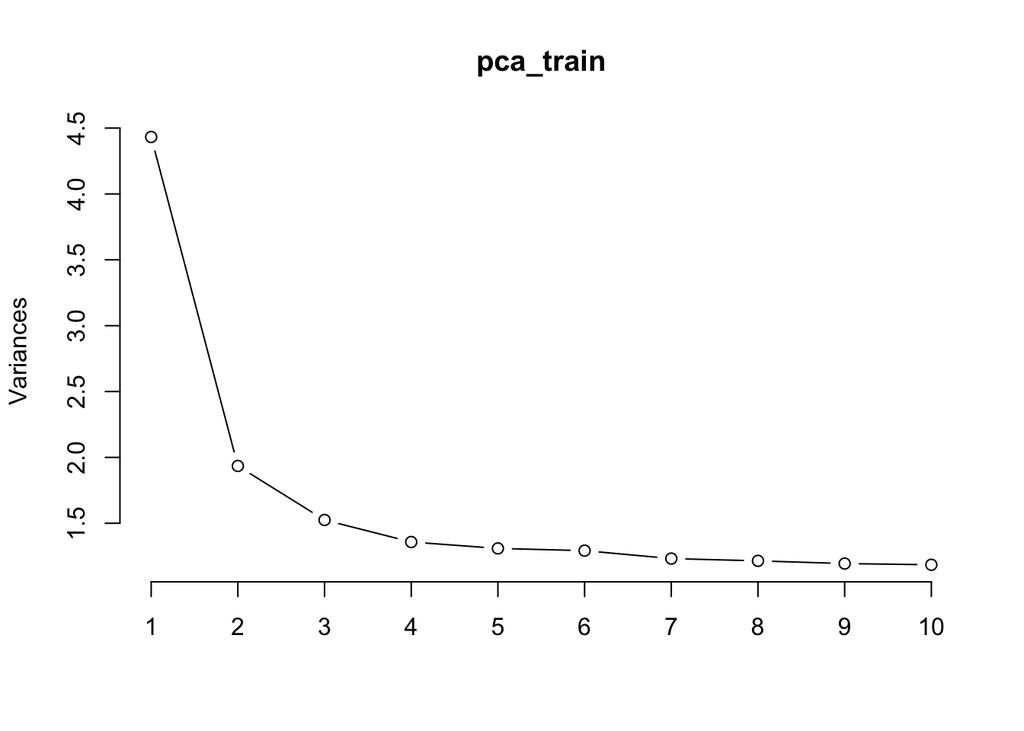

```r
screeplot(pca_train, type = "lines")
```

From this scree plot I would say either take the first two or three PCs.

Based on those rule of thumbs (which widely differ, 2 to 14!), I will go with 14. We will be running regularized regressions anyway which will inherently dampen/remove features, so might as well start with a somewhat larger number.

```r
# Extract the PCs
how_many = 14
dia_train_use <- data.frame(price = dia_train$price, dia_train_pca, pca_train$x[,
    1:how_many])
# dia_train_use <-
# data.frame(price=dia_train$price,pca_train$x[,1:how_many])

# Quick look head(dia_train_use)
```

###### “…fit 10 regularized regression models using random samples of the training data…. Repeat for different values of lambda and observe the results.”

For this next part we will just model with varying $\alpha$. We’ll run $\alpha$’s in 10 increments from `0` (i.e. ridge) up to `1` (i.e. elastic net through to lasso).

Based on the reading of the problem, it seems to imply assuming a constant level of $\lambda$ across all models for the first run-through, but for efficiency we’ll model at varying levels of $\lambda$ now. We’ll also use `cv.glmnet` to automate the $\lambda$ selection.

But before we run the regressions, since we’ll be utilizing a loop, let’s set up our test data set know based on the 14 PCs we selected.

```r
# Remove target and binarized variables from test ---------------

# Subset the data without the target variable
dia_test_pca <- dia_test[, -(which(names(dia_test) == tgt))]

# Subset the data without the newly binarized variable(s)
dia_test_pca <- dia_test_pca[, !(names(dia_test_pca) %in% fctrs)]

# Use predict to apply PCA loadings
library(tidyverse)  #piping is awesome
dia_test_use <- as_tibble(predict(pca_train, newdata = dia_test_pca)) %>% select(PC1:PC14)

# Tack on price variable
dia_test_use <- data.frame(price = dia_test$price, dia_test_pca, dia_test_use)
# dia_test_use <- data.frame(price=dia_test$price, dia_test_use)
# names(dia_test_use)
```

OK! Let’s run regressions.

For $\alpha$’s, I just selected an arbitrary `10`, roughly equally spaced apart, making sure to include `0` and `1`.

Let’s set up the formula and model:

```r
# ------------------------------------------------------
library(glmnet)  #regressions

# Set up the formula (model form)
formula.lm <- as.formula(paste("price~", paste(names(dia_train_use[, -(which(names(dia_train_use) ==
    tgt))]), collapse = "+")))
```

```r
# Here is a clever way to create the data matrix. This one doesn't require
# keeping track of which columns contain the features.
X <- model.matrix(formula.lm, data = dia_train_use)
X.test <- model.matrix(formula.lm, data = dia_test_use)
# dim(dia_train_use) names(dia_train_use)

# Initialize variables
alphas <- c(0, 0.01, 0.1, 0.25, 0.33, 0.5, 0.66, 0.75, 0.9, 1)  #Arbitrarily set
# lambdas <- c(0.0001, 0.01, 0.1 )

list.res.dia <- list()  #List to store coefficients later
rmses_train <- double()  # Vector to store mses
rmses_test <- double()  # Vector to store mses
lambda_mins <- double()  # Store lamdba min for each alpha model
# nzeros <- double()
ncoefs <- double()
counter = 1
```

Next, loop through the 10 $\alpha$ models.

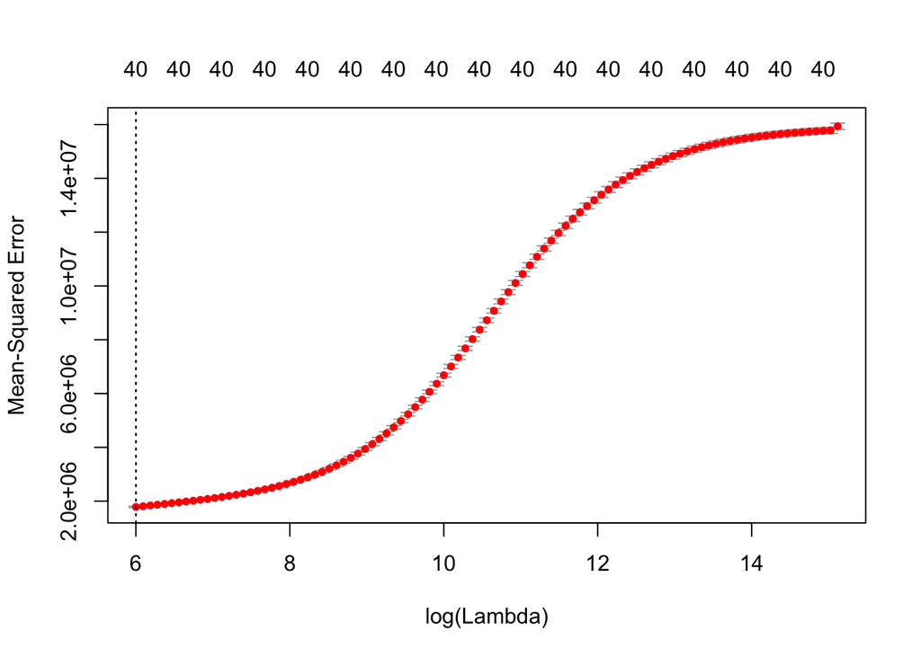

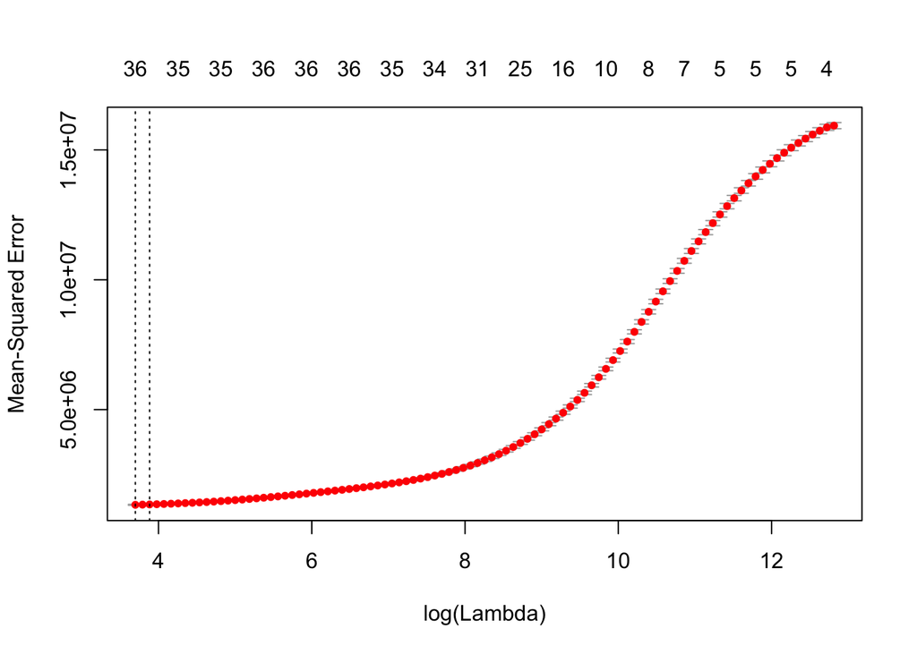

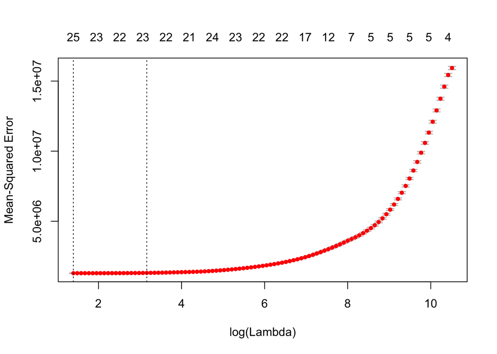

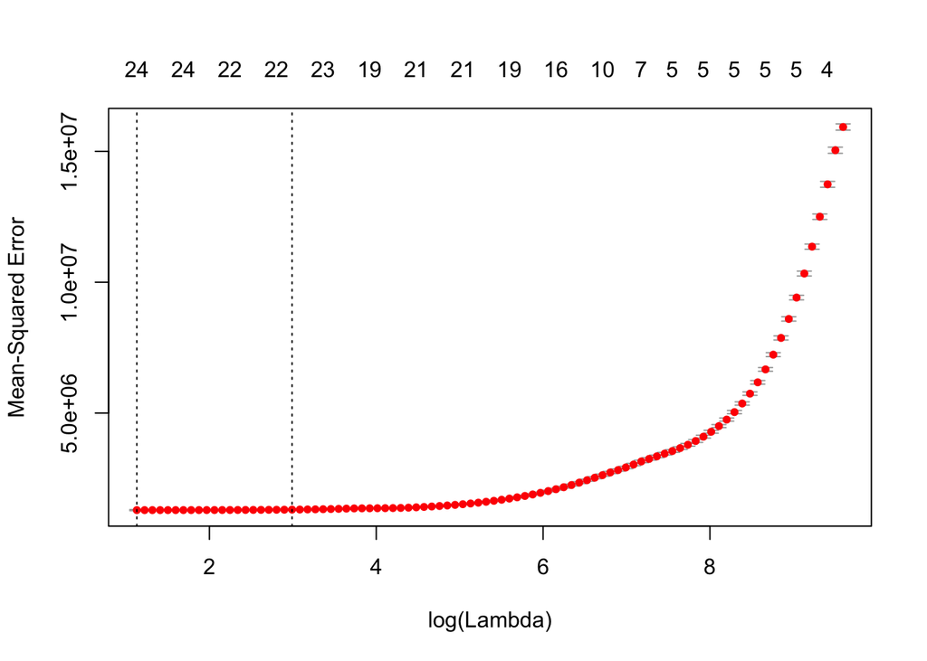

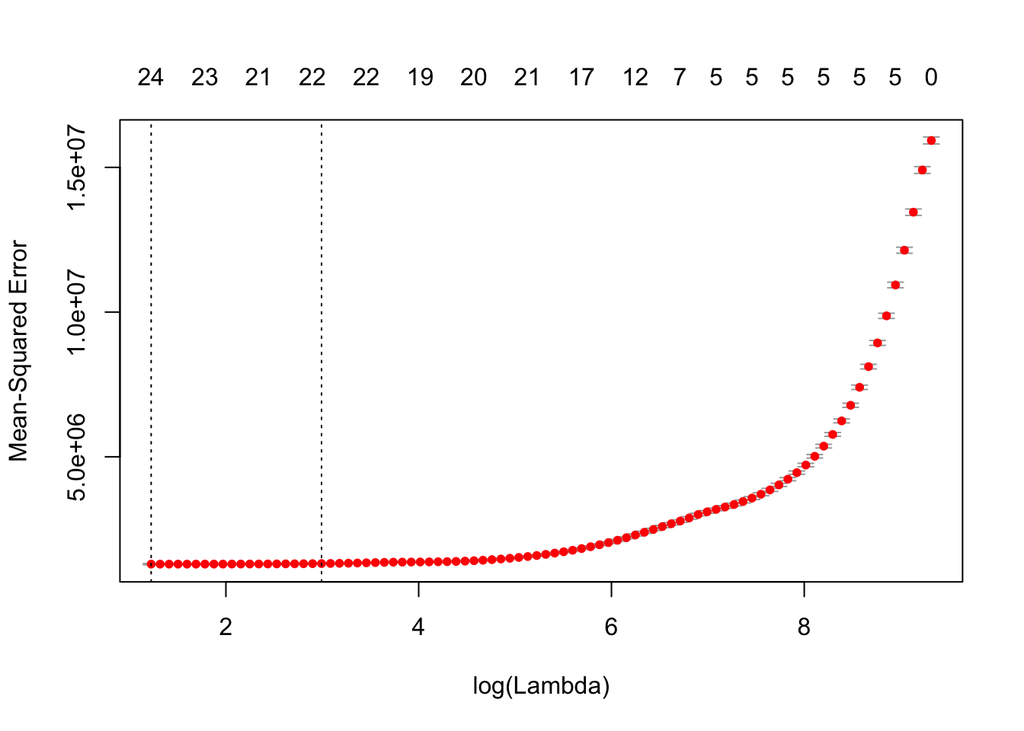

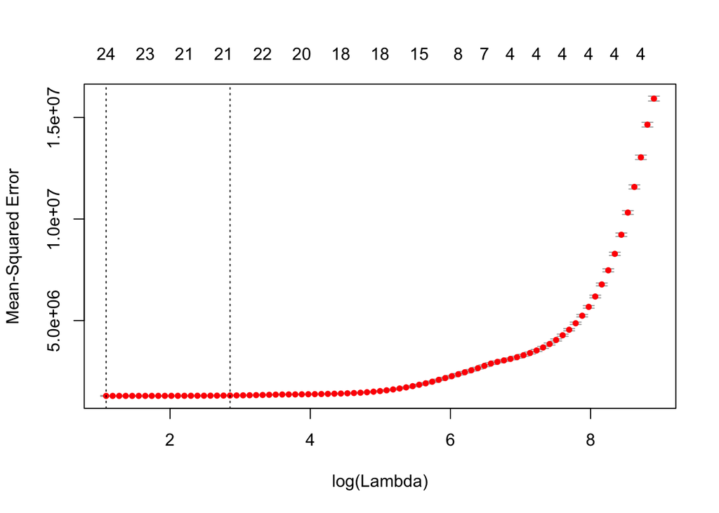

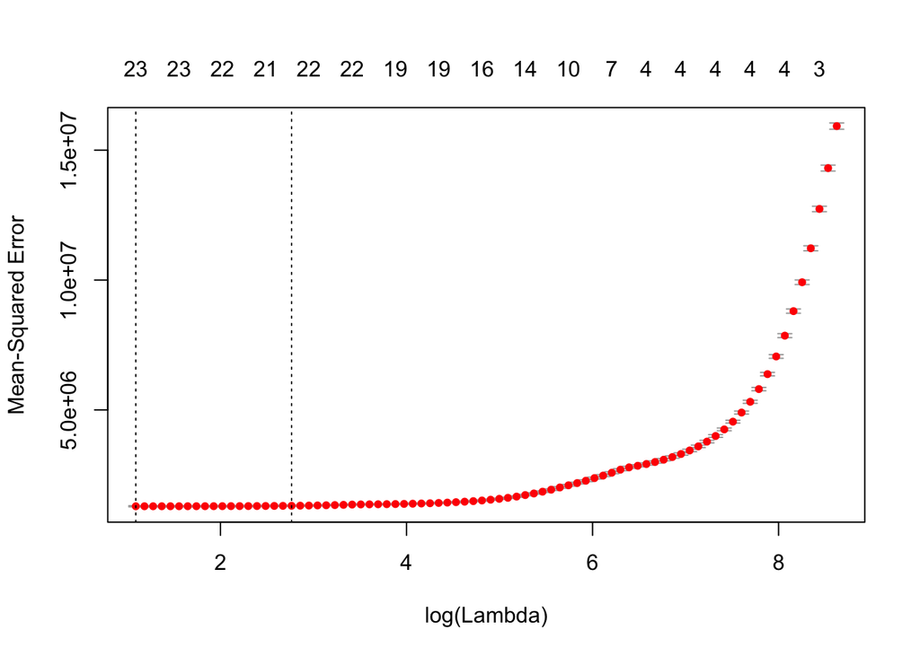

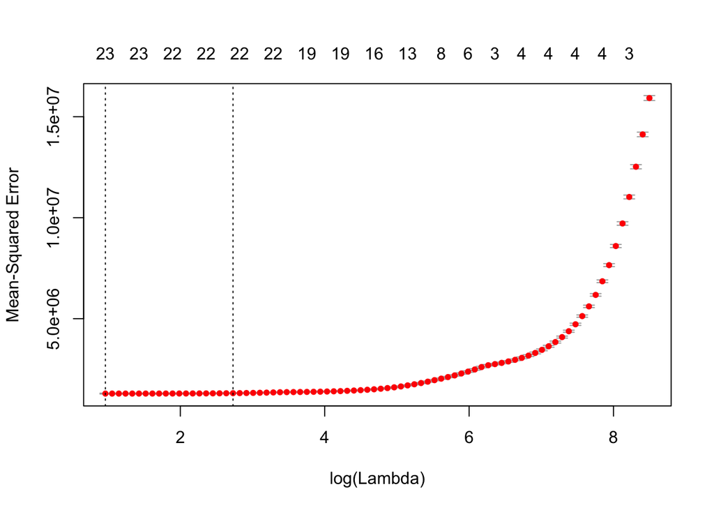

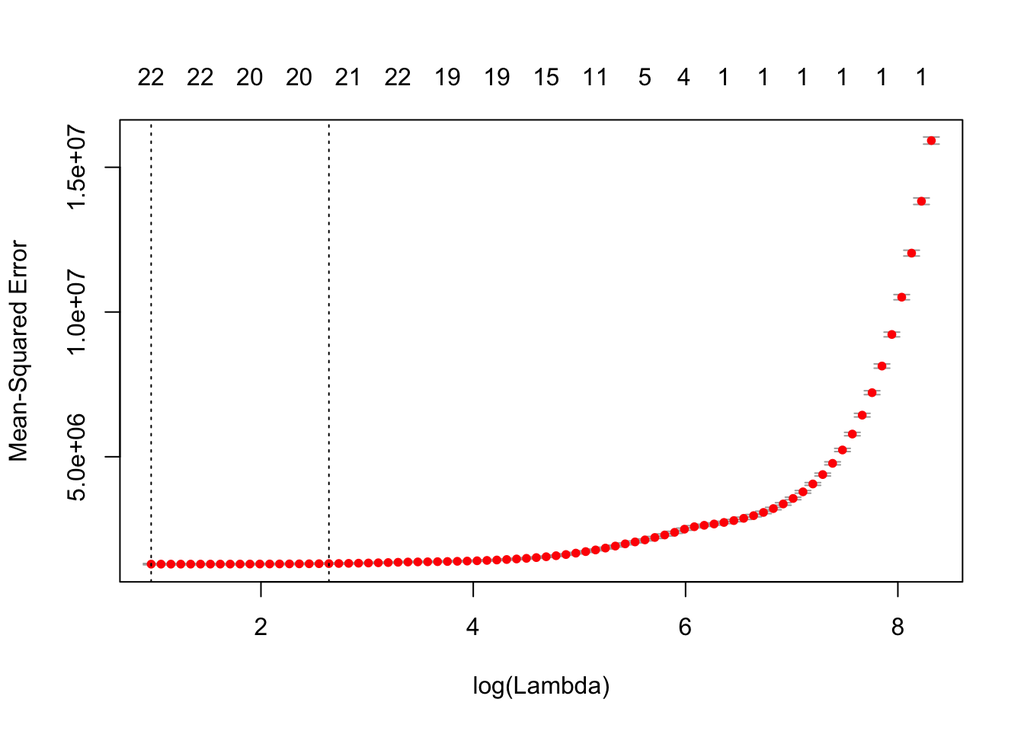

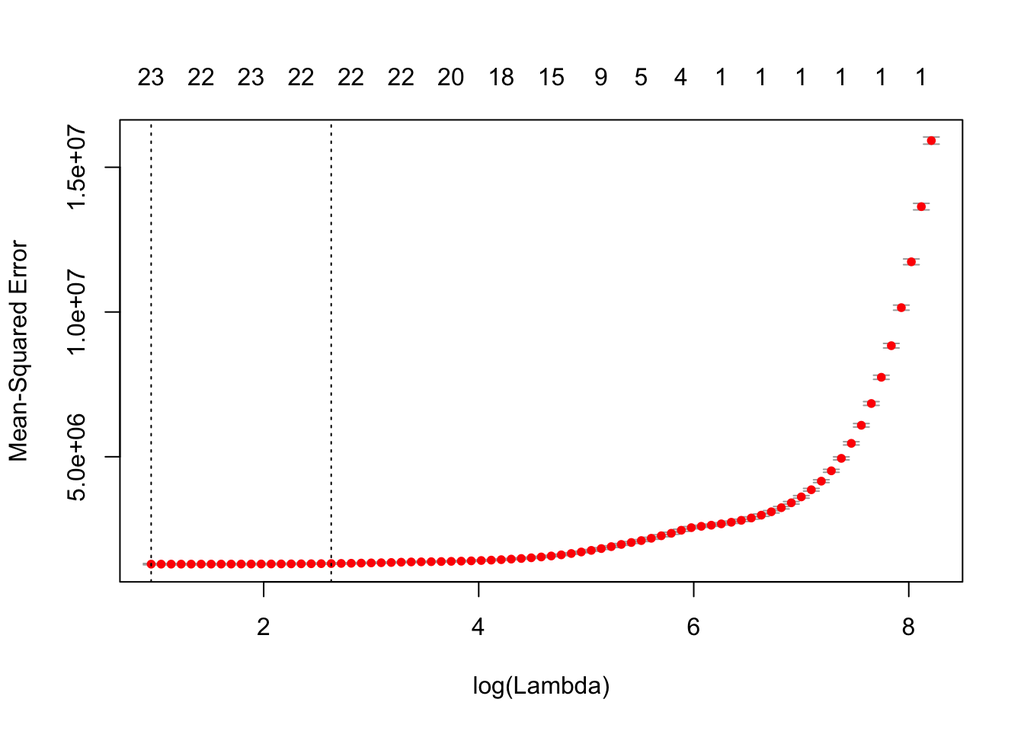

```r
# Loop through alphas and do a cv fit
for (a in alphas) {

    # Run models ------------------------------------------------------ Save
    # foldid's from first model and use them for subsequent models, for
    # consistency and reproducability
    if (counter == 1) {
        curr_cvfit <- cv.glmnet(X, y = dia_train_use$price, alpha = a, type.measure = "mse",
            keep = TRUE)
        common_folds <- curr_cvfit$foldid
    } else {
        curr_cvfit <- cv.glmnet(X, y = dia_train_use$price, alpha = a, type.measure = "mse",
            foldid = common_folds)
    }

    # Collect outputs ---------------------------------------------------
    plot(curr_cvfit)

    # Get root mean cv error for lambda.min
    rmses_train <- c(rmses_train, sqrt(curr_cvfit$cvm[which(curr_cvfit$lambda ==
        curr_cvfit$lambda.min)]))

    # Calc RMSEs for test set
    pred_test <- predict(curr_cvfit, newx = X.test, s = "lambda.min")
    rmses_test <- c(rmses_test, sqrt(mean((dia_test_use$price - pred_test)^2)))

    # Get lambda mins
    lambda_mins <- c(lambda_mins, curr_cvfit$lambda.min)

    # num of coef
    ncoefs <- c(ncoefs, curr_cvfit$nzero[which(curr_cvfit$lambda == curr_cvfit$lambda.min)])

    counter = counter + 1
}
```

```r
# Collect results into a df
results <- data.frame(alpha = alphas, lambda = lambda_mins, rmses_train = rmses_train,
    rmses_test = rmses_test, ncoefs = ncoefs)
```

```r
kable(results, caption = "Modeling Results") %>% kable_styling(full_width = FALSE) %>%
    row_spec(which.min(rmses_train), background = "red", color = "white") %>%
    row_spec(which.min(rmses_test), background = "orange", color = "white")
```

Modeling Results

| alpha | lambda | rmses_train | rmses_test | ncoefs |
| --- | --- | --- | --- | --- |
| 0.00 | 403.618905 | 1335.781 | 1363.465 | 40 |
| 0.01 | 40.361891 | 1155.464 | 1136.121 | 36 |
| 0.10 | 4.036189 | 1136.162 | 1113.962 | 25 |
| 0.25 | 3.096419 | 1136.000 | 1113.116 | 24 |
| 0.33 | 3.403314 | 1136.085 | 1113.112 | 24 |
| 0.50 | 2.969327 | 1136.031 | 1112.897 | 24 |
| 0.66 | 2.973694 | 1136.073 | 1112.893 | 23 |
| 0.75 | 2.616851 | 1136.007 | 1112.716 | 23 |
| 0.90 | 2.626672 | 1136.161 | 1112.634 | 22 |
| 1.00 | 2.594492 | 1136.221 | 1112.468 | 23 |

##### Observations

- The training model with the lowest RMSE has an $\alpha$=0.25 and $\lambda$~3.1 (highlighted in red).
- Note that for $\alpha$>=0.25 the RMSE for the training data doesn’t really change.
- For test set, the RMSE demonstrated similar stability. It’s actually a little lower than train, which helps alleviate a little fear with regards to overfitting to train, I think.
- Test set had least error at the Lasso model ($\alpha$=1), with $\lambda$~2.6.
- Note that the number of non-zero coefficients also basically stables off after $\alpha$=0.25; between 22 to 24 variables being ‘kept’. But we do see it reduce.
- So with regards to the discussion on bias-variance tradeoff: we see a reduction in complexity in increasing alpha ( 40 coefficients down to 23 ), but we do see a rise in model error (`rmses_train`);from $\alpha$=0.25 where training error is at minimum, it starts to increase again as alpha increases.

#### But really, how much for these diamonds?

We’ll leave with the following. The scatter plot below is a comparison of actual price (x) vs predicted price (y) on the test set (using whatever the last model was).

The blue line is a 45 degree line. If the prices were perfectly predicted they all the points below would fall along that line; they do not :). Even note the that there are some negative predicted prices! Obviously this is not a great model.

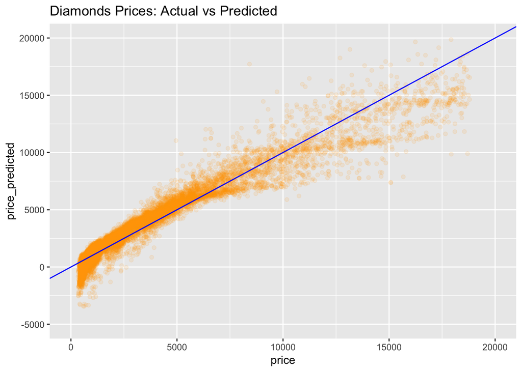

```r
# Get prices, actual and predicted
dat <- data.frame(dia_test_use$price, pred_test)
colnames(dat) <- c("price", "price_predicted")

p <- ggplot(dat, aes(x = price, y = price_predicted)) + geom_point(alpha = 0.1,
    color = "orange") + xlim(0, 20000) + ylim(-5000, 20000) + geom_abline(intercept = 0,
    slope = 1, color = "blue") + ggtitle("Diamonds Prices: Actual vs Predicted")
p
```